# Hw1

HyeongHwan Kim

2023-09-20

# Setting

```r
install.packages('palmerpenguins')
```

```r
library(ggplot2)
library(palmerpenguins)
```

# Textbook 2.2.5

## Problem 4

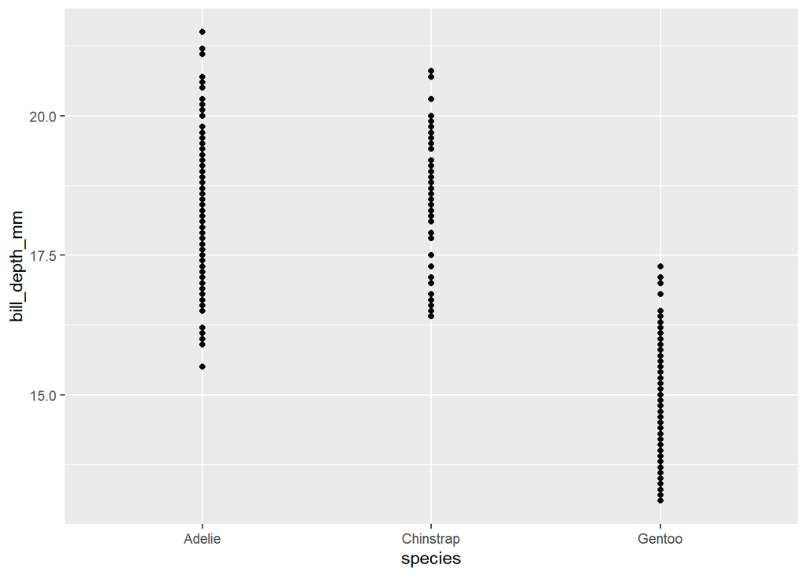

```r
ggplot(data = penguins, mapping = aes(x = species, y = bill_depth_mm)) +
  geom_point()
```

Boxplot would be better.

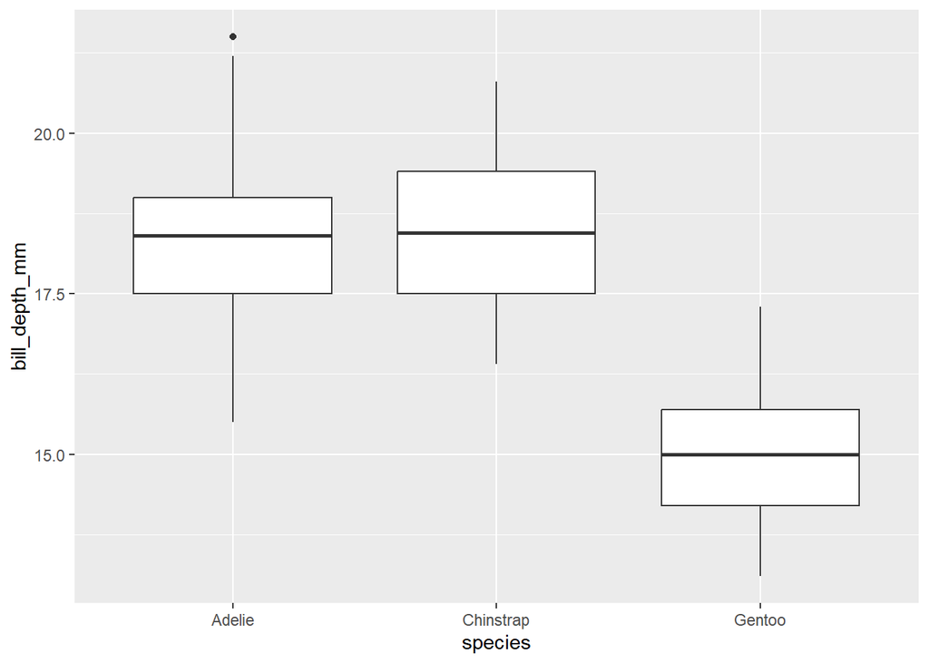

```r
ggplot(data = penguins, mapping = aes(x = species, y = bill_depth_mm)) +
  geom_boxplot()
```

## Problem 5

```r
ggplot(data = penguins) +
  geom_point()
```

mapping parameter should NOT be blank.

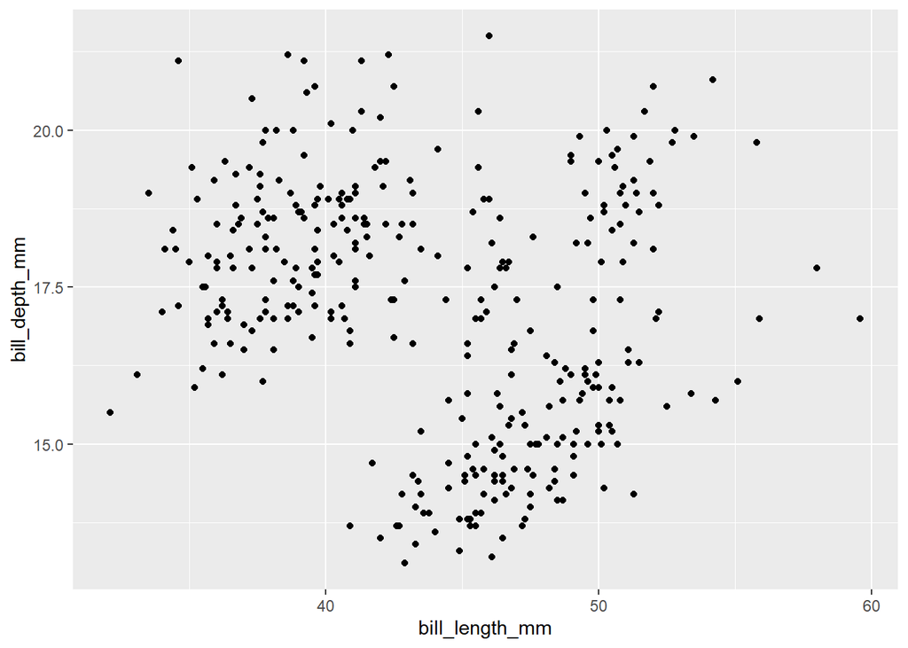

```r
ggplot(data = penguins) +
  geom_point(mapping = aes(x = bill_length_mm, y = bill_depth_mm))
```

# Textbook 2.4.3

## Problem 3

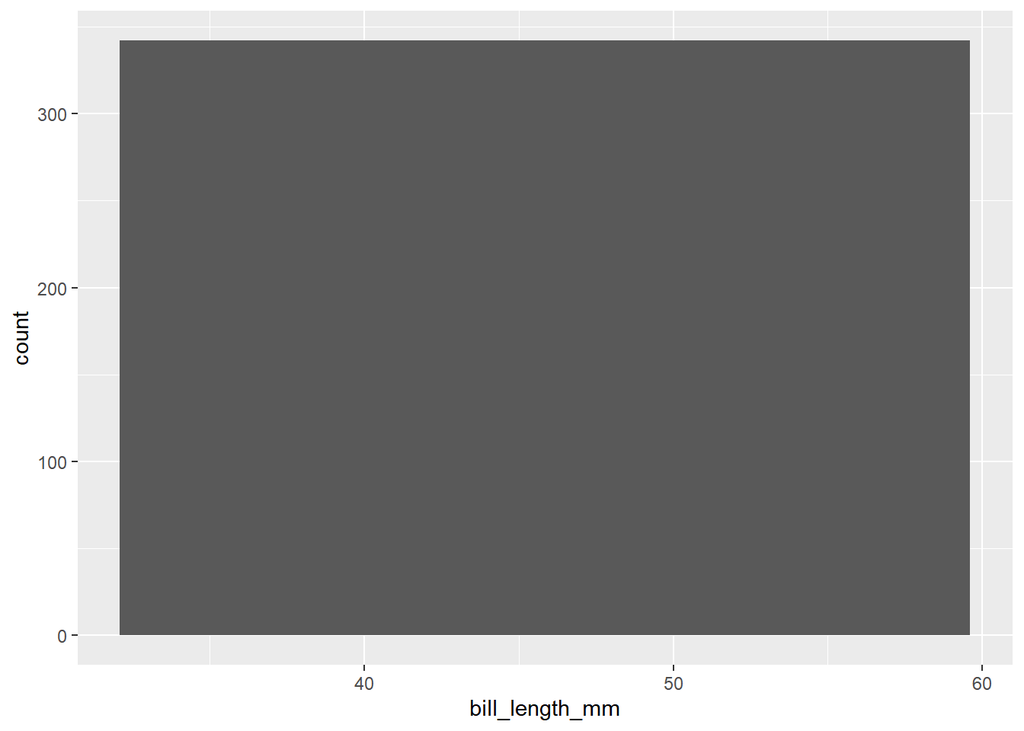

```r
ggplot(penguins, mapping = aes(x = bill_length_mm)) +
  geom_histogram(bins = 1)
```

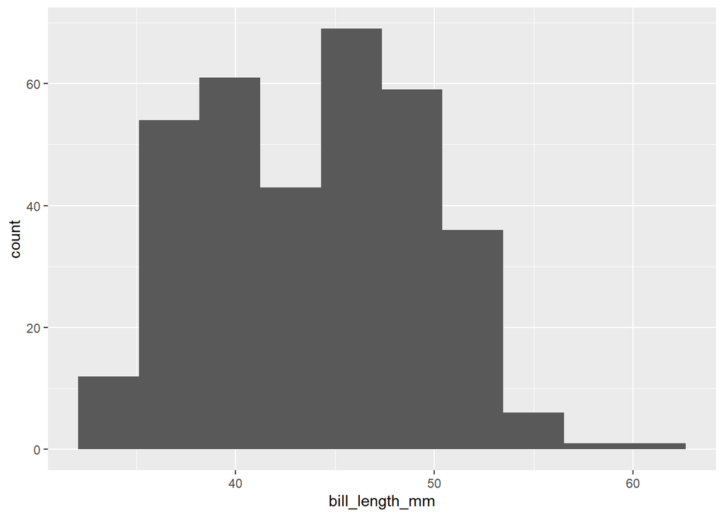

```r
ggplot(penguins, mapping = aes(x = bill_length_mm)) +
  geom_histogram(bins = 10)
```

The parameter ‘bin’ means the number of bars showed on the histogram. For example, there is only one bar on the graph when the value of bin is 1.

# Textbook 2.5.5

## Problem 2

```r
head(mpg, 3)
```

```
## # A tibble: 3 × 11
##   manufacturer model displ  year   cyl trans      drv     cty   hwy fl    class
##   <chr>        <chr> <dbl> <int> <int> <chr>      <chr> <int> <int> <chr> <chr>
## 1 audi         a4      1.8  1999     4 auto(l5)   f        18    29 p     compa…
## 2 audi         a4      1.8  1999     4 manual(m5) f        21    29 p     compa…
## 3 audi         a4      2    2008     4 manual(m6) f        20    31 p     compa…
```

```r
?mpg
```

```
## httpd 도움말 서버를 시작합니다 ... 완료
```

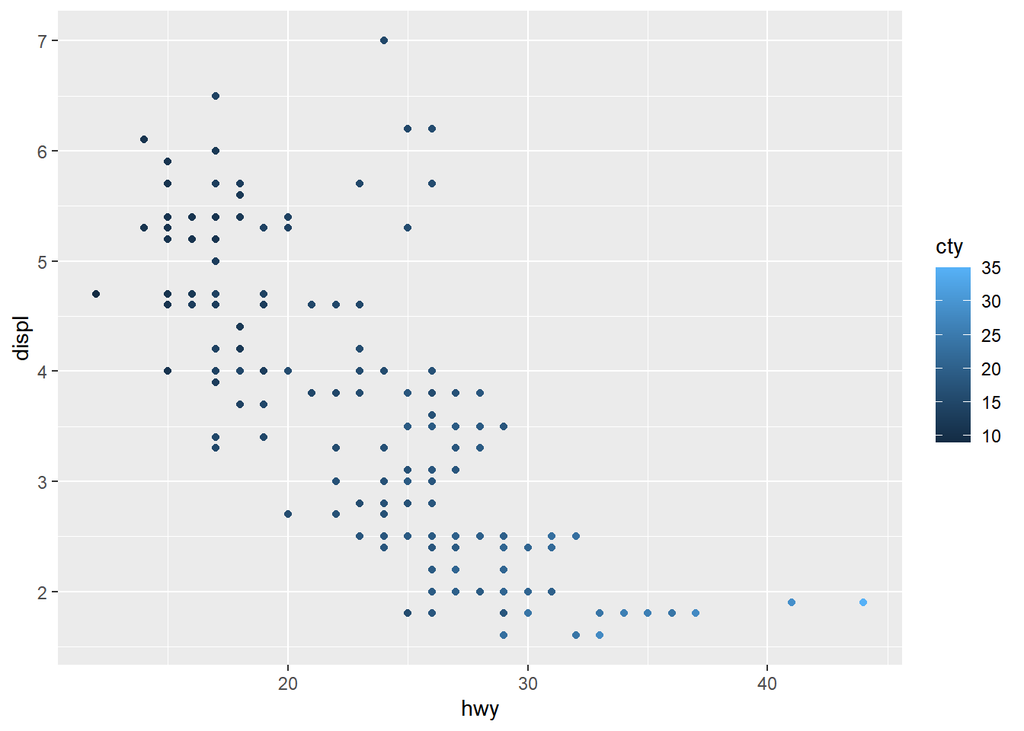

```r
ggplot(data = mpg, mapping = aes(x = hwy, y = displ)) +
  geom_point(aes(color = cty))
```

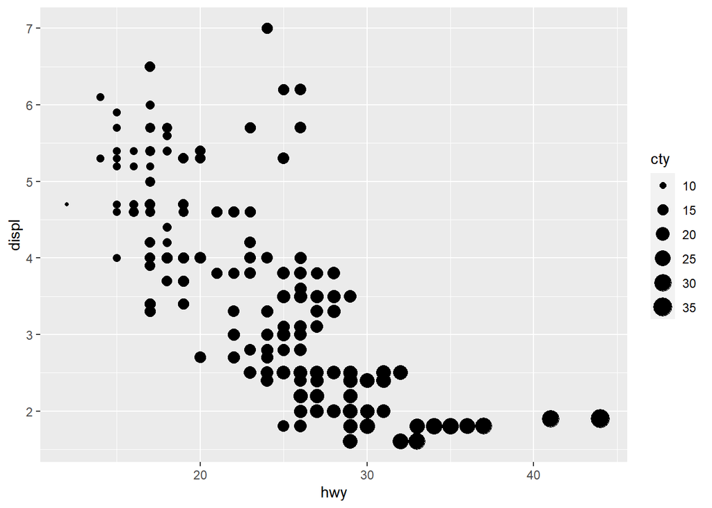

```r
ggplot(data = mpg, mapping = aes(x = hwy, y = displ)) +
  geom_point(aes(size = cty))
```

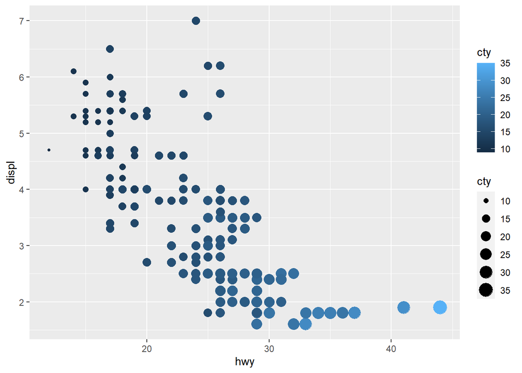

```r
ggplot(data = mpg, mapping = aes(x = hwy, y = displ)) +
  geom_point(aes(color = cty, size = cty))
```

```r
ggplot(data = mpg, mapping = aes(x = hwy, y = displ)) +
  geom_point(aes(shape = cty))
```

A numerical variable is recognized continuous, so it cannot be used for the value of shape parameter. It’s because a domain of continuous variable is uncountable, but the number of shape parameter is not.

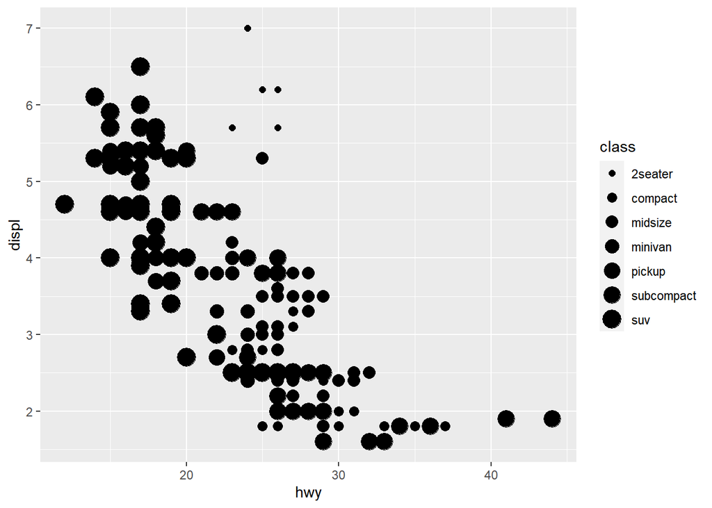

```r
ggplot(data = mpg, mapping = aes(x = hwy, y = displ)) +
  geom_point(aes(size = class))
```

For other parameters (e.g. size, color), if using numerical variables, the plot shows ‘categorized variable’ by dividing the range of the data. However, if using categorical variables, just shows the variables as the they are.